# R Basics

## Basic Building Blocks

```r
5+7
```

12

```r
x<-5+7 #x equals to five plus seven
x
```

12

```r
y<-x-3
y
```

9

#### Any object that contains data is called a data structure and numeric vectors are the simplest type of data structure in R.

#### The easiest way to create a vector is with the c() function, which stands for 'concatenate' or 'combine'.

```r
z<-c(1,2.2,3)
z
```

1. 1

2. 2.2

3. 3

```r
#for help use ?funcation_name will give the documentation
?c
```

```r
#combining the vectors
c(z,555,z)
```

1. 1

2. 2.2

3. 3

4. 555

5. 1

6. 2.2

7. 3

```r
#operations on vector
z*2+100
```

1. 102

2. 104.4

3. 106

#### Other common arithmetic operators are `+`, `-`, `/`, and `^` (where x^2 means 'x squared'). To take the square root, use the sqrt() function and to take the absolute value, use the abs() function.

```r
my_sqrt<-sqrt(z-1)
my_sqrt
```

1. 0

2. 1.09544511501033

3. 1.4142135623731

```r
my_div<-z/my_sqrt
my_div
```

1. Inf

2. 2.00831604418561

3. 2.12132034355964

#### When given two vectors of the same length, R simply performs the specified arithmetic operation (`+`, `-`, `*`, etc.) element-by-element. If the vectors are of different lengths, R 'recycles' the shorter vector until it is the same length as the longer vector.

```r
#example
c(1,2,3,4)+c(0,10)
```

1. 1

2. 12

3. 3

4. 14

```r
#incase longer vetor is not a multiple of shorter vector
c(1,2,3,4)+c(0,10,100)
```

1. 1

2. 12

3. 103

4. 4

## Workspace and Files

```r
#Determine which directory your R session is using as its current working directory using getwd().
getwd()
```

'/Users/prashanth/DS-14.310x'

```r
# List all the objects in your local workspace using ls()
ls()
```

1. 'my_div'

2. 'my_sqrt'

3. 'x'

4. 'y'

5. 'z'

```r
#List all the files in your working directory using list.files() or dir().
list.files()
```

1. '14 310x Intro to R.ipynb'

2. '14_310x_Intro_to_R_.zip'

3. 'RStudio-1.1.453.dmg'

```r
dir()
```

1. '14 310x Intro to R.ipynb'

2. '14_310x_Intro_to_R_.zip'

3. 'RStudio-1.1.453.dmg'

```r
#Using the args() function on a function name is also a handy way to see what arguments a function can take.
args(list.files)
```

```
function (path = ".", pattern = NULL, all.files = FALSE, full.names = FALSE,
    recursive = FALSE, ignore.case = FALSE, include.dirs = FALSE,
    no.. = FALSE)
NULL
```

```r
#Use dir.create() to create a directory in the current working directory called "testdir".
dir.create("testdir")
```

```r
#Set your working directory to "testdir" with the setwd() command.
setwd("testdir")
```

```r
#Create a file in your working directory called "mytest.R" using the file.create() function.
file.create("mytest.R")
```

TRUE

```r
list.files()
```

'mytest.R'

```r
#Check to see if "mytest.R" exists in the working directory using the file.exists() function.
file.exists("mytest.R")
```

TRUE

```r
#Access information about the file "mytest.R" by using file.info().
file.info("mytest.R")
```

|  | size | isdir | mode | mtime | ctime | atime | uid | gid | uname | grname |
| --- | --- | --- | --- | --- | --- | --- | --- | --- | --- | --- |
| mytest.R | 0 | FALSE | 644 | 2018-06-06 09:55:04 | 2018-06-06 09:55:04 | 2018-06-06 09:55:04 | 501 | 20 | prashanth | staff |

```r
#You can use the $ operator --- e.g., file.info("mytest.R")$mode --- to grab specific items.
```

```r
#Change the name of the file "mytest.R" to "mytest2.R" by using file.rename().
file.rename("mytest.R","mytest2.R")
```

TRUE

```r
#Make a copy of "mytest2.R" called "mytest3.R" using file.copy().
file.copy("mytest2.R","mytest3.R")
```

TRUE

```r
#Provide the relative path to the file "mytest3.R" by using file.path().
file.path("mytest3.R")
```

'mytest3.R'

```r
#You can use file.path to construct file and directory paths that are independent of the operating system
#your R code is running on. Pass 'folder1' and 'folder2' as arguments to file.path to make a
# platform-independent pathname.
file.path("folder1","folder2")
```

'folder1/folder2'

```r
# Create a directory in the current working directory called "testdir2" and a subdirectory for it called
# "testdir3", all in one command by using dir.create() and file.path().
dir.create(file.path("testdir2","testdir3"), recursive = TRUE)
```

```r
# To delete a directory you need to use the recursive = TRUE argument with the function unlink(). If you
# don't use recursive = TRUE, R is concerned that you're unaware that you're deleting a directory and all
# of its contents. R reasons that, if you don't specify that recursive equals TRUE, you don't know that
# something is in the directory you're trying to delete. R tries to prevent you from making a mistake.
unlink("testdir2") #dosen't work
```

```r
unlink("testdir2", recursive = TRUE) #works
```

```r
getwd()
```

'/Users/prashanth/DS-14.310x/testdir'

```r
setwd('/Users/prashanth/DS-14.310x')
```

```r
getwd()
```

'/Users/prashanth/DS-14.310x'

```r
list.files()
```

1. '14 310x Intro to R.ipynb'

2. '14_310x_Intro_to_R_.zip'

3. 'RStudio-1.1.453.dmg'

4. 'testdir'

```r
#Delete the 'testdir' directory that you just left (and everything in it)
unlink("testdir", recursive = TRUE)
```

## Sequences of Numbers

```r
#The simplest way to create a sequence of numbers in R is by using the `:` operator. Type 1:20 to see how it works.
1:20
```

1. 1

2. 2

3. 3

4. 4

5. 5

6. 6

7. 7

8. 8

9. 9

10. 10

11. 11

12. 12

13. 13

14. 14

15. 15

16. 16

17. 17

18. 18

19. 19

20. 20

```r
pi:10
```

1. 3.14159265358979

2. 4.14159265358979

3. 5.14159265358979

4. 6.14159265358979

5. 7.14159265358979

6. 8.14159265358979

7. 9.14159265358979

```r
15:1
```

1. 15

2. 14

3. 13

4. 12

5. 11

6. 10

7. 9

8. 8

9. 7

10. 6

11. 5

12. 4

13. 3

14. 2

15. 1

```r
#Documentation for operators, Pull up the documentation for `:` now.
?`:`
```

```r
# Often, we'll desire more control over a sequence we're creating than what the `:` operator gives us. The
# seq() function serves this purpose.
seq(1,20)
```

1. 1

2. 2

3. 3

4. 4

5. 5

6. 6

7. 7

8. 8

9. 9

10. 10

11. 11

12. 12

13. 13

14. 14

15. 15

16. 16

17. 17

18. 18

19. 19

20. 20

```r
seq(1,10, by=0.5) #by half increments
```

1. 1

2. 1.5

3. 2

4. 2.5

5. 3

6. 3.5

7. 4

8. 4.5

9. 5

10. 5.5

11. 6

12. 6.5

13. 7

14. 7.5

15. 8

16. 8.5

17. 9

18. 9.5

19. 10

```r
my_seq<-seq(5, 10,length=30)
my_seq#30 breaks between numbers
```

1. 5

2. 5.17241379310345

3. 5.3448275862069

4. 5.51724137931035

5. 5.68965517241379

6. 5.86206896551724

7. 6.03448275862069

8. 6.20689655172414

9. 6.37931034482759

10. 6.55172413793103

11. 6.72413793103448

12. 6.89655172413793

13. 7.06896551724138

14. 7.24137931034483

15. 7.41379310344828

16. 7.58620689655172

17. 7.75862068965517

18. 7.93103448275862

19. 8.10344827586207

20. 8.27586206896552

21. 8.44827586206897

22. 8.62068965517241

23. 8.79310344827586

24. 8.96551724137931

25. 9.13793103448276

26. 9.31034482758621

27. 9.48275862068965

28. 9.6551724137931

29. 9.82758620689655

30. 10

```r
length(my_seq)
```

30

```r
1:length(my_seq)
```

1. 1

2. 2

3. 3

4. 4

5. 5

6. 6

7. 7

8. 8

9. 9

10. 10

11. 11

12. 12

13. 13

14. 14

15. 15

16. 16

17. 17

18. 18

19. 19

20. 20

21. 21

22. 22

23. 23

24. 24

25. 25

26. 26

27. 27

28. 28

29. 29

30. 30

```r
seq(along.with=my_seq)
```

1. 1

2. 2

3. 3

4. 4

5. 5

6. 6

7. 7

8. 8

9. 9

10. 10

11. 11

12. 12

13. 13

14. 14

15. 15

16. 16

17. 17

18. 18

19. 19

20. 20

21. 21

22. 22

23. 23

24. 24

25. 25

26. 26

27. 27

28. 28

29. 29

30. 30

```r
seq_along(my_seq)
```

1. 1

2. 2

3. 3

4. 4

5. 5

6. 6

7. 7

8. 8

9. 9

10. 10

11. 11

12. 12

13. 13

14. 14

15. 15

16. 16

17. 17

18. 18

19. 19

20. 20

21. 21

22. 22

23. 23

24. 24

25. 25

26. 26

27. 27

28. 28

29. 29

30. 30

```r
#One more function related to creating sequences of numbers is rep(), which stands for 'replicate'. Let's
#look at a few uses.
rep(0, times= 40)
```

1. 0

2. 0

3. 0

4. 0

5. 0

6. 0

7. 0

8. 0

9. 0

10. 0

11. 0

12. 0

13. 0

14. 0

15. 0

16. 0

17. 0

18. 0

19. 0

20. 0

21. 0

22. 0

23. 0

24. 0

25. 0

26. 0

27. 0

28. 0

29. 0

30. 0

31. 0

32. 0

33. 0

34. 0

35. 0

36. 0

37. 0

38. 0

39. 0

40. 0

```r
rep(c(0,1,2), times = 10)#repeating vector
```

1. 0

2. 1

3. 2

4. 0

5. 1

6. 2

7. 0

8. 1

9. 2

10. 0

11. 1

12. 2

13. 0

14. 1

15. 2

16. 0

17. 1

18. 2

19. 0

20. 1

21. 2

22. 0

23. 1

24. 2

25. 0

26. 1

27. 2

28. 0

29. 1

30. 2

```r
rep(c(0, 1, 2), each = 10) # repeat each number 10 times
```

1. 0

2. 0

3. 0

4. 0

5. 0

6. 0

7. 0

8. 0

9. 0

10. 0

11. 1

12. 1

13. 1

14. 1

15. 1

16. 1

17. 1

18. 1

19. 1

20. 1

21. 2

22. 2

23. 2

24. 2

25. 2

26. 2

27. 2

28. 2

29. 2

30. 2

## Vectors

#### The simplest and most common data structure in R is the vector. Vectors come in two different flavors: atomic vectors and lists. An atomic vector contains exactly one data type, whereas a list may contain multiple data types.

#### Types of atomic vectors include logical, character, integer, and complex. Logical vectors can contain the values TRUE, FALSE, and NA (for 'not available'). These values are generated as the result of logical 'conditions'.

```r
num_vect<-c(0.5,55,-10,6)
tf <- num_vect < 1
tf
```

1. TRUE

2. FALSE

3. TRUE

4. FALSE

```r
num_vect>=6
```

1. FALSE

2. TRUE

3. FALSE

4. TRUE

#### The `<` and `>=` symbols in these examples are called 'logical operators'. Other logical operators include `>`, `<=`, `==` for exact equality, and `!=` for inequality.

#### If we have two logical expressions, A and B, we can ask whether at least one is TRUE with A | B (logical 'or' a.k.a. 'union') or whether they are both TRUE with A & B (logical 'and' a.k.a. 'intersection'). Lastly, !A is the negation of A and is TRUE when A is FALSE and vice versa.

```r
(3 > 5) & (4 == 4)
```

FALSE

```r
(TRUE == TRUE) | (TRUE == FALSE)
```

TRUE

```r
((111 >= 111) | !(TRUE)) & ((4 + 1) == 5)
```

TRUE

```r
# Create a character vector that contains the following words: "My", "name", "is". Remember to enclose each
# word in its own set of double quotes, so that R knows they are character strings. Store the vector in a
# variable called my_char.
my_char<-c("My","name","is")
my_char
```

1. 'My'

2. 'name'

3. 'is'

```r
paste(my_char, collapse = " ")#combines the strings in a vector
```

'My name is'

```r
my_name=c(my_char,"chika chika slam shady")#string concatination
my_name
```

1. 'My'

2. 'name'

3. 'is'

4. 'chika chika slam shady'

```r
paste(my_name, collapse = " ")
```

'My name is chika chika slam shady'

```r
paste("Hello", "world!", sep = " ")
```

'Hello world!'

```r
paste(1:3,c("X","Y","Z"),sep="") #integrs and charactors
```

1. '1X'

2. '2Y'

3. '3Z'

```r
#Try paste(LETTERS, 1:4, sep = "-"), where LETTERS is a predefined variable in R
# containing a character vector of all 26 letters in the English alphabet.
paste(LETTERS, 1:4, sep = "-")
```

1. 'A-1'

2. 'B-2'

3. 'C-3'

4. 'D-4'

5. 'E-1'

6. 'F-2'

7. 'G-3'

8. 'H-4'

9. 'I-1'

10. 'J-2'

11. 'K-3'

12. 'L-4'

13. 'M-1'

14. 'N-2'

15. 'O-3'

16. 'P-4'

17. 'Q-1'

18. 'R-2'

19. 'S-3'

20. 'T-4'

21. 'U-1'

22. 'V-2'

23. 'W-3'

24. 'X-4'

25. 'Y-1'

26. 'Z-2'

#### Note: If the lenghts of the vectors are not equal the the shorter vector repates

## Missing Values

#### Missing values play an important role in statistics and data analysis. Often, missing values must not be ignored, but rather they should be carefully studied to see if there's an underlying pattern or cause for their missingness.

#### In R, NA is used to represent any value that is 'not available' or 'missing' (in the statistical sense). In this lesson, we'll explore missing values further. Any operation involving NA generally yields NA as the result.

```r
x<-c(44,NA,5,NA)
x*3
```

1. 132

2. <NA>

3. 15

4. <NA>

```r
y <- rnorm(1000) # vector containing 1000 draws from a standard normal distribution
z<- rep(NA, 1000) # vector of NA's
my_data <- sample(c(y,z), 100) #collecting random 100 sample from both the vectors
my_na <- is.na(my_data) #TRUE if value is  NA else FALSE
my_na
```

1. FALSE

2. FALSE

3. TRUE

4. TRUE

5. FALSE

6. FALSE

7. TRUE

8. FALSE

9. FALSE

10. TRUE

11. TRUE

12. TRUE

13. TRUE

14. FALSE

15. FALSE

16. FALSE

17. TRUE

18. FALSE

19. TRUE

20. FALSE

21. FALSE

22. TRUE

23. TRUE

24. FALSE

25. FALSE

26. FALSE

27. TRUE

28. FALSE

29. FALSE

30. TRUE

31. TRUE

32. TRUE

33. FALSE

34. TRUE

35. TRUE

36. FALSE

37. TRUE

38. TRUE

39. TRUE

40. FALSE

41. TRUE

42. TRUE

43. TRUE

44. FALSE

45. FALSE

46. TRUE

47. TRUE

48. FALSE

49. TRUE

50. TRUE

51. TRUE

52. TRUE

53. TRUE

54. TRUE

55. FALSE

56. TRUE

57. TRUE

58. FALSE

59. TRUE

60. TRUE

61. TRUE

62. FALSE

63. TRUE

64. TRUE

65. FALSE

66. FALSE

67. TRUE

68. FALSE

69. FALSE

70. TRUE

71. TRUE

72. TRUE

73. FALSE

74. FALSE

75. FALSE

76. TRUE

77. TRUE

78. FALSE

79. TRUE

80. TRUE

81. FALSE

82. FALSE

83. FALSE

84. TRUE

85. FALSE

86. FALSE

87. TRUE

88. FALSE

89. TRUE

90. FALSE

91. FALSE

92. TRUE

93. FALSE

94. TRUE

95. TRUE

96. FALSE

97. TRUE

98. TRUE

99. TRUE

100. TRUE

```r
my_data == NA # wont work , just gives NA's of vector lenght. Careful !
```

1. <NA>

2. <NA>

3. <NA>

4. <NA>

5. <NA>

6. <NA>

7. <NA>

8. <NA>

9. <NA>

10. <NA>

11. <NA>

12. <NA>

13. <NA>

14. <NA>

15. <NA>

16. <NA>

17. <NA>

18. <NA>

19. <NA>

20. <NA>

21. <NA>

22. <NA>

23. <NA>

24. <NA>

25. <NA>

26. <NA>

27. <NA>

28. <NA>

29. <NA>

30. <NA>

31. <NA>

32. <NA>

33. <NA>

34. <NA>

35. <NA>

36. <NA>

37. <NA>

38. <NA>

39. <NA>

40. <NA>

41. <NA>

42. <NA>

43. <NA>

44. <NA>

45. <NA>

46. <NA>

47. <NA>

48. <NA>

49. <NA>

50. <NA>

51. <NA>

52. <NA>

53. <NA>

54. <NA>

55. <NA>

56. <NA>

57. <NA>

58. <NA>

59. <NA>

60. <NA>

61. <NA>

62. <NA>

63. <NA>

64. <NA>

65. <NA>

66. <NA>

67. <NA>

68. <NA>

69. <NA>

70. <NA>

71. <NA>

72. <NA>

73. <NA>

74. <NA>

75. <NA>

76. <NA>

77. <NA>

78. <NA>

79. <NA>

80. <NA>

81. <NA>

82. <NA>

83. <NA>

84. <NA>

85. <NA>

86. <NA>

87. <NA>

88. <NA>

89. <NA>

90. <NA>

91. <NA>

92. <NA>

93. <NA>

94. <NA>

95. <NA>

96. <NA>

97. <NA>

98. <NA>

99. <NA>

100. <NA>

#### underneath the surface, R represents TRUE as the number 1 and FALSE as the number 0.

```r
sum(my_na) #sum will give us how many TRUE
```

56

```r
#let's look at a second type of missing value -- NaN, which stands for 'not a number'.
0/0
```

NaN

```r
Inf-Inf #Inf stands for infinity
```

NaN

## Subsetting Vectors

#### In this lesson, we'll see how to extract elements from a vector based on some conditions that we specify.

```r
x <- rep(c(NA,2.5,NA,-1),10) #sample vector
x
```

1. <NA>

2. 2.5

3. <NA>

4. -1

5. <NA>

6. 2.5

7. <NA>

8. -1

9. <NA>

10. 2.5

11. <NA>

12. -1

13. <NA>

14. 2.5

15. <NA>

16. -1

17. <NA>

18. 2.5

19. <NA>

20. -1

21. <NA>

22. 2.5

23. <NA>

24. -1

25. <NA>

26. 2.5

27. <NA>

28. -1

29. <NA>

30. 2.5

31. <NA>

32. -1

33. <NA>

34. 2.5

35. <NA>

36. -1

37. <NA>

38. 2.5

39. <NA>

40. -1

```r
#The way you tell R that you want to select some particular elements
#(i.e. a 'subset') from a vector is by placing an 'index vector' in
#square brackets immediately following the name of the vector.
```

```r
x[1:10] #first 10 elements
```

1. <NA>

2. 2.5

3. <NA>

4. -1

5. <NA>

6. 2.5

7. <NA>

8. -1

9. <NA>

10. 2.5

```r
# Index vectors come in four different flavors -- logical vectors, vectors
# of positive integers, vectors of negative integers, and vectors of
# character strings
```

```r
x[is.na(x)] # gives all NA's in vector
```

1. <NA>

2. <NA>

3. <NA>

4. <NA>

5. <NA>

6. <NA>

7. <NA>

8. <NA>

9. <NA>

10. <NA>

11. <NA>

12. <NA>

13. <NA>

14. <NA>

15. <NA>

16. <NA>

17. <NA>

18. <NA>

19. <NA>

20. <NA>

```r
y<-x[!is.na(x)]
y #!is.na() is used - negation '!'. Gives all non NA elements
```

1. 2.5

2. -1

3. 2.5

4. -1

5. 2.5

6. -1

7. 2.5

8. -1

9. 2.5

10. -1

11. 2.5

12. -1

13. 2.5

14. -1

15. 2.5

16. -1

17. 2.5

18. -1

19. 2.5

20. -1

```r
y[y>0] #all y values where y>0
```

1. 2.5

2. 2.5

3. 2.5

4. 2.5

5. 2.5

6. 2.5

7. 2.5

8. 2.5

9. 2.5

10. 2.5

```r
x[!is.na(x) & x>0] # combination of above commands
```

1. 2.5

2. 2.5

3. 2.5

4. 2.5

5. 2.5

6. 2.5

7. 2.5

8. 2.5

9. 2.5

10. 2.5

### Many programming languages use what's called 'zero-based indexing', which means that the first element of a vector is considered element 0. R uses 'one-based indexing', which (you guessed it!) means the first element of a vector is considered element 1.

```r
x[1] #is the 1st element
```

<NA>

```r
x[c(3,4,7)] #3rd 4th and 7th element
```

1. <NA>

2. -1

3. <NA>

```r
x[0] #gives nothing
```

```r
x[3000] #gives NA hence be carful about the lenght of the vector
```

<NA>

```r
x[c(-2,-10)] #gives all the elemnts other than 2nd and 10th
```

1. <NA>

2. <NA>

3. -1

4. <NA>

5. 2.5

6. <NA>

7. -1

8. <NA>

9. <NA>

10. -1

11. <NA>

12. 2.5

13. <NA>

14. -1

15. <NA>

16. 2.5

17. <NA>

18. -1

19. <NA>

20. 2.5

21. <NA>

22. -1

23. <NA>

24. 2.5

25. <NA>

26. -1

27. <NA>

28. 2.5

29. <NA>

30. -1

31. <NA>

32. 2.5

33. <NA>

34. -1

35. <NA>

36. 2.5

37. <NA>

38. -1

```r
x[-c(2,10)] #similar to above command
```

1. <NA>

2. <NA>

3. -1

4. <NA>

5. 2.5

6. <NA>

7. -1

8. <NA>

9. <NA>

10. -1

11. <NA>

12. 2.5

13. <NA>

14. -1

15. <NA>

16. 2.5

17. <NA>

18. -1

19. <NA>

20. 2.5

21. <NA>

22. -1

23. <NA>

24. 2.5

25. <NA>

26. -1

27. <NA>

28. 2.5

29. <NA>

30. -1

31. <NA>

32. 2.5

33. <NA>

34. -1

35. <NA>

36. 2.5

37. <NA>

38. -1

```r
vect <- c(foo = 11, bar= 2, norf=NA) #named index vectors
vect
```

**foo**

11

**bar**

2

**norf**

<NA>

```r
names(vect) #gives all the names
```

1. 'foo'

2. 'bar'

3. 'norf'

```r
vect2 <- c(11,2,NA) #creating the vector
names(vect2) <- c("foo","bar","norf") #assigning the names
vect2
```

**foo**

11

**bar**

2

**norf**

<NA>

```r
identical(vect,vect2) #checks for identical vectors
```

TRUE

```r
vect["bar"] #selecting based on name
```

**bar:** 2

```r
vect[c("foo","bar")] #multiple selection based on name
```

**foo**

11

**bar**

2

## Matrices and Data Frames

### In this lesson, we'll cover matrices and data frames. Both represent 'rectangular' data types, meaning that they are used to store tabular data, with rows and columns.

```r
# | The main difference, as you'll see, is that matrices can only contain a
# | single class of data, while data frames can consist of many different
# | classes of data.
```

```r
my_vector <- 1:20
my_vector
```

1. 1

2. 2

3. 3

4. 4

5. 5

6. 6

7. 7

8. 8

9. 9

10. 10

11. 11

12. 12

13. 13

14. 14

15. 15

16. 16

17. 17

18. 18

19. 19

20. 20

```r
dim(my_vector) #vector has no dimensions
```

```r
length(my_vector) #but it has length
```

20

```r
dim(my_vector)<- c(4,5) #assigning dimensions 4 rows and 5 column
my_vector
```

| 1 | 5 | 9 | 13 | 17 |
| --- | --- | --- | --- | --- |
| 2 | 6 | 10 | 14 | 18 |
| 3 | 7 | 11 | 15 | 19 |
| 4 | 8 | 12 | 16 | 20 |

```r
dim(my_vector)
```

1. 4

2. 5

```r
attributes(my_vector)
```

**$dim** =

1. 4

2. 5

```r
class(my_vector) #now its type matrix
```

'matrix'

```r
my_matrix <- my_vector
my_matrix2 = matrix(data=1:20, nrow= 4, ncol= 5) #another way of creating the matrix
my_matrix2
```

| 1 | 5 | 9 | 13 | 17 |
| --- | --- | --- | --- | --- |
| 2 | 6 | 10 | 14 | 18 |
| 3 | 7 | 11 | 15 | 19 |
| 4 | 8 | 12 | 16 | 20 |

```r
identical(my_matrix,my_matrix2)
```

TRUE

```r
patients<- c("Bill","Gina","Kelly","Sean")
cbind(patients,my_matrix) #converts every element in the matrix to string which is not good for working with numbers.
                            #This is called 'implicit coercion', because we didn't ask for it.
```

| patients |  |  |  |  |  |
| --- | --- | --- | --- | --- | --- |
| Bill | 1 | 5 | 9 | 13 | 17 |
| Gina | 2 | 6 | 10 | 14 | 18 |
| Kelly | 3 | 7 | 11 | 15 | 19 |
| Sean | 4 | 8 | 12 | 16 | 20 |

```r
#Hence better way to do it use data frames
my_data <- data.frame(patients,my_matrix)
my_data
```

| patients | X1 | X2 | X3 | X4 | X5 |
| --- | --- | --- | --- | --- | --- |
| Bill | 1 | 5 | 9 | 13 | 17 |
| Gina | 2 | 6 | 10 | 14 | 18 |
| Kelly | 3 | 7 | 11 | 15 | 19 |
| Sean | 4 | 8 | 12 | 16 | 20 |

```r
# Behind the scenes, the data.frame() function takes any number of
#| arguments and returns a single object of class `data.frame` that is
#| composed of the original objects.
class(my_data)
```

'data.frame'

```r
cnames <- c("patient","age","weight","bp","rating","test")
colnames(my_data) <- cnames #adding column name to data frame
my_data
```

| patient | age | weight | bp | rating | test |
| --- | --- | --- | --- | --- | --- |
| Bill | 1 | 5 | 9 | 13 | 17 |
| Gina | 2 | 6 | 10 | 14 | 18 |
| Kelly | 3 | 7 | 11 | 15 | 19 |
| Sean | 4 | 8 | 12 | 16 | 20 |

## Looking at Data

```r
# | Whenever you're working with a new dataset, the first thing you should
# | do is look at it! What is the format of the data? What are the
# | dimensions? What are the variable names? How are the variables stored?
# | Are there missing data? Are there any flaws in the data?
```

```r
laliga=read.csv("SP1.csv")
```

```r
ls()
```

1. 'cnames'

2. 'laliga'

3. 'my_char'

4. 'my_data'

5. 'my_div'

6. 'my_matrix'

7. 'my_matrix2'

8. 'my_na'

9. 'my_name'

10. 'my_seq'

11. 'my_sqrt'

12. 'my_vector'

13. 'num_vect'

14. 'P'

15. 'patients'

16. 'Q'

17. 'tf'

18. 'vect'

19. 'vect2'

20. 'x'

21. 'y'

22. 'z'

```r
class(laliga) #object type
```

'data.frame'

```r
dim(laliga) #dimensions
```

1. 380

2. 64

```r
nrow(laliga) # number of rows
```

380

```r
ncol(laliga) #number of columns
```

64

```r
object.size(laliga) #size of the file interms of space occupied on machine
```

```
177552 bytes
```

```r
names(laliga) #column names
```

1. 'Div'

2. 'Date'

3. 'HomeTeam'

4. 'AwayTeam'

5. 'FTHG'

6. 'FTAG'

7. 'FTR'

8. 'HTHG'

9. 'HTAG'

10. 'HTR'

11. 'HS'

12. 'AS'

13. 'HST'

14. 'AST'

15. 'HF'

16. 'AF'

17. 'HC'

18. 'AC'

19. 'HY'

20. 'AY'

21. 'HR'

22. 'AR'

23. 'B365H'

24. 'B365D'

25. 'B365A'

26. 'BWH'

27. 'BWD'

28. 'BWA'

29. 'IWH'

30. 'IWD'

31. 'IWA'

32. 'LBH'

33. 'LBD'

34. 'LBA'

35. 'PSH'

36. 'PSD'

37. 'PSA'

38. 'WHH'

39. 'WHD'

40. 'WHA'

41. 'VCH'

42. 'VCD'

43. 'VCA'

44. 'Bb1X2'

45. 'BbMxH'

46. 'BbAvH'

47. 'BbMxD'

48. 'BbAvD'

49. 'BbMxA'

50. 'BbAvA'

51. 'BbOU'

52. 'BbMx.2.5'

53. 'BbAv.2.5'

54. 'BbMx.2.5.1'

55. 'BbAv.2.5.1'

56. 'BbAH'

57. 'BbAHh'

58. 'BbMxAHH'

59. 'BbAvAHH'

60. 'BbMxAHA'

61. 'BbAvAHA'

62. 'PSCH'

63. 'PSCD'

64. 'PSCA'

```r
head(laliga) #first 6 rows deafult
```

| Div | Date | HomeTeam | AwayTeam | FTHG | FTAG | FTR | HTHG | HTAG | HTR | ⋯ | BbAv.2.5.1 | BbAH | BbAHh | BbMxAHH | BbAvAHH | BbMxAHA | BbAvAHA | PSCH | PSCD | PSCA |
| --- | --- | --- | --- | --- | --- | --- | --- | --- | --- | --- | --- | --- | --- | --- | --- | --- | --- | --- | --- | --- |
| SP1 | 18/08/17 | Leganes | Alaves | 1 | 0 | H | 1 | 0 | H | ⋯ | 1.46 | 18 | -0.50 | 2.07 | 2.03 | 1.90 | 1.86 | 1.98 | 3.35 | 4.63 |
| SP1 | 18/08/17 | Valencia | Las Palmas | 1 | 0 | H | 1 | 0 | H | ⋯ | 2.27 | 16 | -0.75 | 2.05 | 1.97 | 1.96 | 1.91 | 1.78 | 4.24 | 4.43 |
| SP1 | 19/08/17 | Celta | Sociedad | 2 | 3 | A | 1 | 1 | D | ⋯ | 1.84 | 18 | -0.25 | 2.08 | 2.05 | 1.87 | 1.83 | 2.12 | 3.53 | 3.74 |
| SP1 | 19/08/17 | Girona | Ath Madrid | 2 | 2 | D | 2 | 0 | H | ⋯ | 1.74 | 16 | 1.25 | 1.77 | 1.75 | 2.25 | 2.16 | 6.93 | 3.83 | 1.63 |
| SP1 | 19/08/17 | Sevilla | Espanol | 1 | 1 | D | 1 | 1 | D | ⋯ | 2.09 | 16 | -1.00 | 2.12 | 2.06 | 1.86 | 1.82 | 1.64 | 4.18 | 5.82 |
| SP1 | 20/08/17 | Ath Bilbao | Getafe | 0 | 0 | D | 0 | 0 | D | ⋯ | 1.87 | 17 | -1.00 | 1.90 | 1.86 | 2.05 | 2.01 | 1.53 | 4.48 | 6.91 |

```r
head(laliga,10) #first 10 rows
```

| Div | Date | HomeTeam | AwayTeam | FTHG | FTAG | FTR | HTHG | HTAG | HTR | ⋯ | BbAv.2.5.1 | BbAH | BbAHh | BbMxAHH | BbAvAHH | BbMxAHA | BbAvAHA | PSCH | PSCD | PSCA |
| --- | --- | --- | --- | --- | --- | --- | --- | --- | --- | --- | --- | --- | --- | --- | --- | --- | --- | --- | --- | --- |
| SP1 | 18/08/17 | Leganes | Alaves | 1 | 0 | H | 1 | 0 | H | ⋯ | 1.46 | 18 | -0.50 | 2.07 | 2.03 | 1.90 | 1.86 | 1.98 | 3.35 | 4.63 |
| SP1 | 18/08/17 | Valencia | Las Palmas | 1 | 0 | H | 1 | 0 | H | ⋯ | 2.27 | 16 | -0.75 | 2.05 | 1.97 | 1.96 | 1.91 | 1.78 | 4.24 | 4.43 |
| SP1 | 19/08/17 | Celta | Sociedad | 2 | 3 | A | 1 | 1 | D | ⋯ | 1.84 | 18 | -0.25 | 2.08 | 2.05 | 1.87 | 1.83 | 2.12 | 3.53 | 3.74 |
| SP1 | 19/08/17 | Girona | Ath Madrid | 2 | 2 | D | 2 | 0 | H | ⋯ | 1.74 | 16 | 1.25 | 1.77 | 1.75 | 2.25 | 2.16 | 6.93 | 3.83 | 1.63 |
| SP1 | 19/08/17 | Sevilla | Espanol | 1 | 1 | D | 1 | 1 | D | ⋯ | 2.09 | 16 | -1.00 | 2.12 | 2.06 | 1.86 | 1.82 | 1.64 | 4.18 | 5.82 |
| SP1 | 20/08/17 | Ath Bilbao | Getafe | 0 | 0 | D | 0 | 0 | D | ⋯ | 1.87 | 17 | -1.00 | 1.90 | 1.86 | 2.05 | 2.01 | 1.53 | 4.48 | 6.91 |
| SP1 | 20/08/17 | Barcelona | Betis | 2 | 0 | H | 2 | 0 | H | ⋯ | 2.88 | 17 | -2.00 | 2.05 | 2.00 | 1.91 | 1.86 | 1.20 | 8.25 | 15.20 |
| SP1 | 20/08/17 | La Coruna | Real Madrid | 0 | 3 | A | 0 | 2 | A | ⋯ | 2.64 | 16 | 1.50 | 2.03 | 1.98 | 1.95 | 1.89 | 12.40 | 7.00 | 1.26 |
| SP1 | 21/08/17 | Levante | Villarreal | 1 | 0 | H | 0 | 0 | D | ⋯ | 1.58 | 15 | 0.25 | 1.93 | 1.89 | 2.03 | 1.98 | 3.31 | 3.32 | 2.40 |
| SP1 | 21/08/17 | Malaga | Eibar | 0 | 1 | A | 0 | 0 | D | ⋯ | 1.70 | 17 | -0.25 | 1.92 | 1.88 | 2.04 | 1.99 | 2.20 | 3.27 | 3.85 |

```r
tail(laliga,15) #last 15 rows
```

|  | Div | Date | HomeTeam | AwayTeam | FTHG | FTAG | FTR | HTHG | HTAG | HTR | ⋯ | BbAv.2.5.1 | BbAH | BbAHh | BbMxAHH | BbAvAHH | BbMxAHA | BbAvAHA | PSCH | PSCD | PSCA |
| --- | --- | --- | --- | --- | --- | --- | --- | --- | --- | --- | --- | --- | --- | --- | --- | --- | --- | --- | --- | --- | --- |
| 366 | SP1 | 12/05/18 | La Coruna | Villarreal | 2 | 4 | A | 0 | 3 | A | ⋯ | 2.15 | 17 | 0.25 | 2.19 | 2.11 | 1.81 | 1.76 | 4.71 | 4.30 | 1.71 |
| 367 | SP1 | 12/05/18 | Real Madrid | Celta | 6 | 0 | H | 3 | 0 | H | ⋯ | 3.94 | 19 | -1.50 | 1.96 | 1.91 | 2.00 | 1.95 | 1.25 | 6.89 | 11.56 |
| 368 | SP1 | 12/05/18 | Sociedad | Leganes | 3 | 2 | H | 2 | 1 | H | ⋯ | 2.04 | 19 | -1.25 | 2.06 | 1.99 | 1.91 | 1.87 | 1.40 | 4.87 | 9.26 |
| 369 | SP1 | 13/05/18 | Espanol | Malaga | 4 | 1 | H | 3 | 1 | H | ⋯ | 1.74 | 19 | -0.75 | 1.86 | 1.83 | 2.07 | 2.03 | 1.63 | 3.97 | 6.24 |
| 370 | SP1 | 13/05/18 | Levante | Barcelona | 5 | 4 | H | 2 | 1 | H | ⋯ | 3.23 | 18 | 1.50 | 2.11 | 2.06 | 1.86 | 1.81 | 7.70 | 5.40 | 1.40 |
| 371 | SP1 | 19/05/18 | Celta | Levante | 4 | 2 | H | 2 | 1 | H | ⋯ | 2.82 | 20 | -0.75 | 2.05 | 2.01 | 1.90 | 1.85 | 1.60 | 4.68 | 5.33 |
| 372 | SP1 | 19/05/18 | Las Palmas | Girona | 1 | 2 | A | 1 | 2 | A | ⋯ | 2.36 | 19 | 0.25 | 1.94 | 1.90 | 2.00 | 1.95 | 3.44 | 4.01 | 2.06 |
| 373 | SP1 | 19/05/18 | Leganes | Betis | 3 | 2 | H | 1 | 1 | D | ⋯ | 2.19 | 17 | 0.00 | 2.04 | 1.99 | 1.91 | 1.86 | 2.41 | 3.76 | 2.90 |
| 374 | SP1 | 19/05/18 | Malaga | Getafe | 0 | 1 | A | 0 | 0 | D | ⋯ | 1.91 | 19 | 0.25 | 1.98 | 1.92 | 1.98 | 1.93 | 3.26 | 3.56 | 2.28 |
| 375 | SP1 | 19/05/18 | Sevilla | Alaves | 1 | 0 | H | 1 | 0 | H | ⋯ | 2.86 | 19 | -1.25 | 1.97 | 1.91 | 2.00 | 1.94 | 1.32 | 6.09 | 9.47 |
| 376 | SP1 | 19/05/18 | Villarreal | Real Madrid | 2 | 2 | D | 0 | 2 | A | ⋯ | 3.79 | 19 | 0.25 | 2.05 | 1.98 | 1.93 | 1.87 | 4.74 | 5.05 | 1.62 |
| 377 | SP1 | 20/05/18 | Ath Bilbao | Espanol | 0 | 1 | A | 0 | 1 | A | ⋯ | 2.06 | 17 | -0.50 | 2.06 | 2.02 | 1.88 | 1.85 | 1.95 | 3.77 | 4.05 |
| 378 | SP1 | 20/05/18 | Ath Madrid | Eibar | 2 | 2 | D | 1 | 1 | D | ⋯ | 1.98 | 19 | -1.00 | 2.09 | 2.04 | 1.87 | 1.82 | 1.47 | 4.25 | 8.80 |
| 379 | SP1 | 20/05/18 | Barcelona | Sociedad | 1 | 0 | H | 0 | 0 | D | ⋯ | 5.04 | 19 | -2.00 | 1.94 | 1.89 | 2.03 | 1.97 | 1.31 | 6.40 | 8.60 |
| 380 | SP1 | 20/05/18 | Valencia | La Coruna | 2 | 1 | H | 1 | 0 | H | ⋯ | 2.98 | 19 | -1.50 | 2.01 | 1.97 | 1.94 | 1.89 | 1.27 | 6.44 | 10.71 |

```r
summary(laliga) #summary!!!
```

```
  Div            Date           HomeTeam         AwayTeam        FTHG
 SP1:380   12/05/18:  8   Alaves    : 19   Alaves    : 19   Min.   :0.000
           19/05/18:  6   Ath Bilbao: 19   Ath Bilbao: 19   1st Qu.:0.750
           01/04/18:  5   Ath Madrid: 19   Ath Madrid: 19   Median :1.000
           01/10/17:  5   Barcelona : 19   Barcelona : 19   Mean   :1.547
           03/03/18:  5   Betis     : 19   Betis     : 19   3rd Qu.:2.000
           05/11/17:  5   Celta     : 19   Celta     : 19   Max.   :7.000
           (Other) :346   (Other)   :266   (Other)   :266
      FTAG       FTR          HTHG             HTAG        HTR
 Min.   :0.000   A:115   Min.   :0.0000   Min.   :0.0000   A: 93
 1st Qu.:0.000   D: 86   1st Qu.:0.0000   1st Qu.:0.0000   D:159
 Median :1.000   H:179   Median :0.0000   Median :0.0000   H:128
 Mean   :1.147           Mean   :0.6605   Mean   :0.4868
 3rd Qu.:2.000           3rd Qu.:1.0000   3rd Qu.:1.0000
 Max.   :6.000           Max.   :5.0000   Max.   :3.0000

       HS              AS             HST              AST
 Min.   : 2.00   Min.   : 1.00   Min.   : 0.000   Min.   : 0.000
 1st Qu.:10.00   1st Qu.: 8.00   1st Qu.: 3.000   1st Qu.: 2.000
 Median :13.00   Median :10.00   Median : 4.500   Median : 3.000
 Mean   :13.53   Mean   :10.47   Mean   : 4.758   Mean   : 3.805
 3rd Qu.:16.00   3rd Qu.:13.00   3rd Qu.: 6.000   3rd Qu.: 5.000
 Max.   :30.00   Max.   :24.00   Max.   :14.000   Max.   :13.000

       HF              AF              HC               AC
 Min.   : 4.00   Min.   : 0.00   Min.   : 0.000   Min.   : 0.000
 1st Qu.:11.00   1st Qu.:11.00   1st Qu.: 4.000   1st Qu.: 2.000
 Median :13.00   Median :14.00   Median : 5.000   Median : 4.000
 Mean   :13.73   Mean   :13.95   Mean   : 5.613   Mean   : 4.192
 3rd Qu.:17.00   3rd Qu.:17.00   3rd Qu.: 7.000   3rd Qu.: 6.000
 Max.   :29.00   Max.   :29.00   Max.   :16.000   Max.   :14.000

       HY              AY              HR               AR
 Min.   :0.000   Min.   :0.000   Min.   :0.0000   Min.   :0.00000
 1st Qu.:1.000   1st Qu.:2.000   1st Qu.:0.0000   1st Qu.:0.00000
 Median :2.000   Median :3.000   Median :0.0000   Median :0.00000
 Mean   :2.339   Mean   :2.676   Mean   :0.1105   Mean   :0.07895
 3rd Qu.:3.000   3rd Qu.:4.000   3rd Qu.:0.0000   3rd Qu.:0.00000
 Max.   :8.000   Max.   :9.000   Max.   :2.0000   Max.   :2.00000

```

[output cut: 73 more lines]

```
 Min.   :1.580   Min.   :1.680   Min.   :1.630   Min.   : 1.060
 1st Qu.:1.840   1st Qu.:1.897   1st Qu.:1.850   1st Qu.: 1.640
 Median :1.930   Median :1.970   Median :1.930   Median : 2.120
 Mean   :1.938   Mean   :1.988   Mean   :1.937   Mean   : 2.839
 3rd Qu.:2.020   3rd Qu.:2.080   3rd Qu.:2.030   3rd Qu.: 2.980
 Max.   :2.340   Max.   :2.520   Max.   :2.440   Max.   :18.700
                                                 NA's   :1
      PSCD             PSCA
 Min.   : 2.930   Min.   : 1.160
 1st Qu.: 3.410   1st Qu.: 2.590
 Median : 3.700   Median : 3.850
 Mean   : 4.508   Mean   : 5.695
 3rd Qu.: 4.560   3rd Qu.: 6.095
 Max.   :18.500   Max.   :46.000
 NA's   :1        NA's   :1
```

```r
table(laliga$HomeTeam) #table for column Home Team
```

```
     Alaves  Ath Bilbao  Ath Madrid   Barcelona       Betis       Celta
         19          19          19          19          19          19
      Eibar     Espanol      Getafe      Girona   La Coruna  Las Palmas
         19          19          19          19          19          19
    Leganes     Levante      Malaga Real Madrid     Sevilla    Sociedad
         19          19          19          19          19          19
   Valencia  Villarreal
         19          19
```

```r
str(laliga) #structure if data
```

```
'data.frame':	380 obs. of  64 variables:
 $ Div       : Factor w/ 1 level "SP1": 1 1 1 1 1 1 1 1 1 1 ...
 $ Date      : Factor w/ 137 levels "01/03/18","01/04/18",..: 75 75 83 83 83 90 90 90 97 97 ...
 $ HomeTeam  : Factor w/ 20 levels "Alaves","Ath Bilbao",..: 13 19 6 10 17 2 4 11 14 15 ...
 $ AwayTeam  : Factor w/ 20 levels "Alaves","Ath Bilbao",..: 1 12 18 3 8 9 5 16 20 7 ...
 $ FTHG      : int  1 1 2 2 1 0 2 0 1 0 ...
 $ FTAG      : int  0 0 3 2 1 0 0 3 0 1 ...
 $ FTR       : Factor w/ 3 levels "A","D","H": 3 3 1 2 2 2 3 1 3 1 ...
 $ HTHG      : int  1 1 1 2 1 0 2 0 0 0 ...
 $ HTAG      : int  0 0 1 0 1 0 0 2 0 0 ...
 $ HTR       : Factor w/ 3 levels "A","D","H": 3 3 2 3 2 2 3 1 2 2 ...
 $ HS        : int  16 22 16 13 9 12 15 12 14 10 ...
 $ AS        : int  6 5 13 9 9 8 3 16 9 13 ...
 $ HST       : int  9 6 5 6 4 2 2 6 3 4 ...
 $ AST       : int  3 4 6 3 6 2 0 8 1 6 ...
```

[output cut: 50 more lines]

## Base Graphics

```r
data(cars)
```

```r
head(cars)
```

| speed | dist |
| --- | --- |
| 4 | 2 |
| 4 | 10 |
| 7 | 4 |
| 7 | 22 |
| 8 | 16 |
| 9 | 10 |

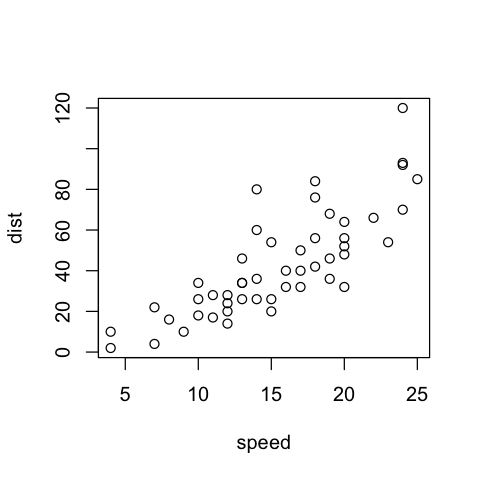

```r
options(repr.plot.width=4, repr.plot.height=4) #reduce the size of the graph , other wise fills up the screen
plot(cars) #choose first column as x axis and second for y
```

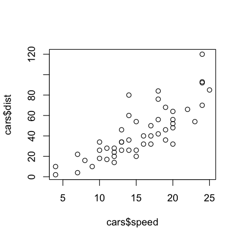

```r
plot(x=cars$speed, y=cars$dist) #specifying the axis
```

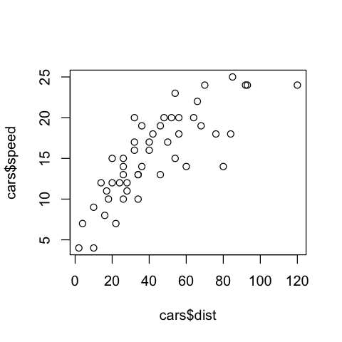

```r
plot(y=cars$speed, x=cars$dist) #swtiching the axis from above
```

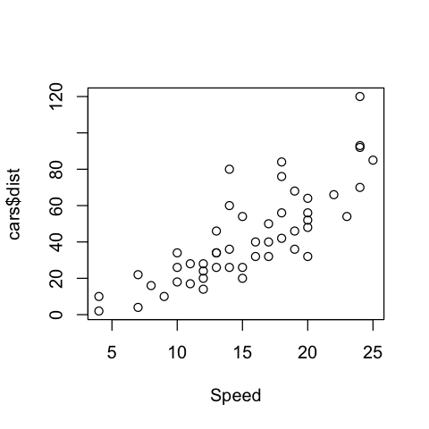

```r
plot(x=cars$speed, y=cars$dist, xlab= "Speed") #labelling the x-axis
```

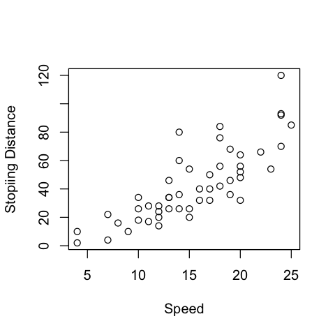

```r
plot(x=cars$speed, y=cars$dist, xlab= "Speed",ylab = "Stopiing Distance") #labeling y-axis
```

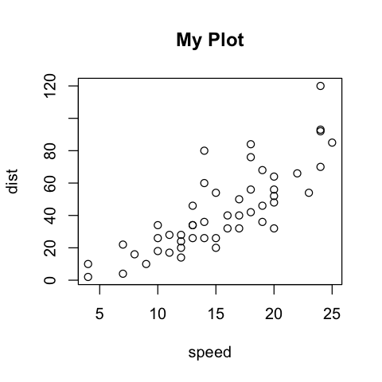

```r
plot(cars,main="My Plot") #title
```

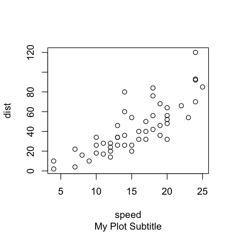

```r
plot(cars,sub="My Plot Subtitle") #sub title
```

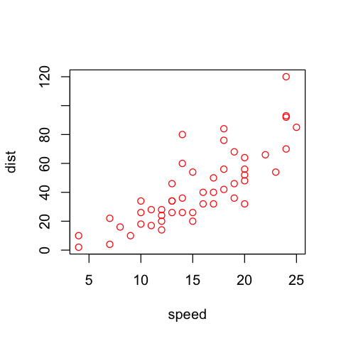

```r
plot(cars,col=2) #change color for the points
```

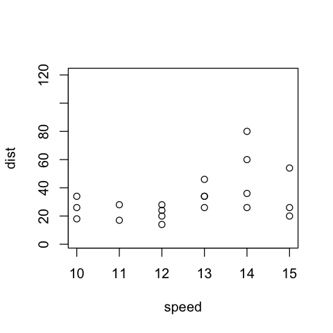

```r
plot(cars,xlim=c(10,15)) #limiting the x-axis
```

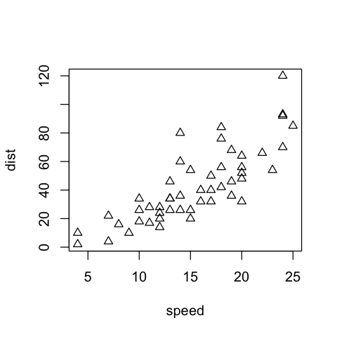

```r
plot(cars,pch=2) #chaning point icon
```

```r
data(mtcars) #loding data-mtcars
```

```r
str(mtcars)
```

```
'data.frame':	32 obs. of  11 variables:
 $ mpg : num  21 21 22.8 21.4 18.7 18.1 14.3 24.4 22.8 19.2 ...
 $ cyl : num  6 6 4 6 8 6 8 4 4 6 ...
 $ disp: num  160 160 108 258 360 ...
 $ hp  : num  110 110 93 110 175 105 245 62 95 123 ...
 $ drat: num  3.9 3.9 3.85 3.08 3.15 2.76 3.21 3.69 3.92 3.92 ...
 $ wt  : num  2.62 2.88 2.32 3.21 3.44 ...
 $ qsec: num  16.5 17 18.6 19.4 17 ...
 $ vs  : num  0 0 1 1 0 1 0 1 1 1 ...
 $ am  : num  1 1 1 0 0 0 0 0 0 0 ...
 $ gear: num  4 4 4 3 3 3 3 4 4 4 ...
 $ carb: num  4 4 1 1 2 1 4 2 2 4 ...
```

```r
head(mtcars)
```

|  | mpg | cyl | disp | hp | drat | wt | qsec | vs | am | gear | carb |
| --- | --- | --- | --- | --- | --- | --- | --- | --- | --- | --- | --- |
| Mazda RX4 | 21.0 | 6 | 160 | 110 | 3.90 | 2.620 | 16.46 | 0 | 1 | 4 | 4 |
| Mazda RX4 Wag | 21.0 | 6 | 160 | 110 | 3.90 | 2.875 | 17.02 | 0 | 1 | 4 | 4 |
| Datsun 710 | 22.8 | 4 | 108 | 93 | 3.85 | 2.320 | 18.61 | 1 | 1 | 4 | 1 |
| Hornet 4 Drive | 21.4 | 6 | 258 | 110 | 3.08 | 3.215 | 19.44 | 1 | 0 | 3 | 1 |
| Hornet Sportabout | 18.7 | 8 | 360 | 175 | 3.15 | 3.440 | 17.02 | 0 | 0 | 3 | 2 |
| Valiant | 18.1 | 6 | 225 | 105 | 2.76 | 3.460 | 20.22 | 1 | 0 | 3 | 1 |

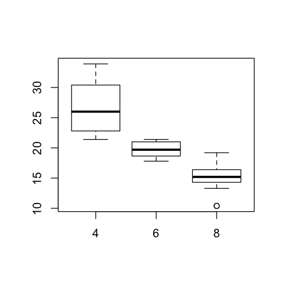

```r
boxplot(mpg ~ cyl , data=mtcars) #box plot
```

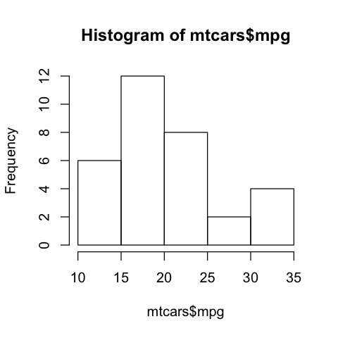

```r
hist(mtcars$mpg) #histogram
```

## Manipulating Data with dplyr

### dplyr is a fast and powerful R package written by Hadley Wickham and Romain Francois that provides a consistent and concise grammar for manipulating tabular data.

```r
library("dplyr") #loading the package
```

```r
packageVersion("dplyr") #check the version
```

```
[1] ‘0.7.4’
```

```r
mydf=read.csv("SP1.csv") #reading the data set to mydf
```

```r
cran<-tbl_df(mydf) #"The main advantage to using a tbl_df over a regular data frame is the printing."
```

```r
cran #jupyter notebook dosen't show tbl_df well
```

| Div | Date | HomeTeam | AwayTeam | FTHG | FTAG | FTR | HTHG | HTAG | HTR | ⋯ | BbAv.2.5.1 | BbAH | BbAHh | BbMxAHH | BbAvAHH | BbMxAHA | BbAvAHA | PSCH | PSCD | PSCA |
| --- | --- | --- | --- | --- | --- | --- | --- | --- | --- | --- | --- | --- | --- | --- | --- | --- | --- | --- | --- | --- |
| SP1 | 18/08/17 | Leganes | Alaves | 1 | 0 | H | 1 | 0 | H | ⋯ | 1.46 | 18 | -0.50 | 2.07 | 2.03 | 1.90 | 1.86 | 1.98 | 3.35 | 4.63 |
| SP1 | 18/08/17 | Valencia | Las Palmas | 1 | 0 | H | 1 | 0 | H | ⋯ | 2.27 | 16 | -0.75 | 2.05 | 1.97 | 1.96 | 1.91 | 1.78 | 4.24 | 4.43 |
| SP1 | 19/08/17 | Celta | Sociedad | 2 | 3 | A | 1 | 1 | D | ⋯ | 1.84 | 18 | -0.25 | 2.08 | 2.05 | 1.87 | 1.83 | 2.12 | 3.53 | 3.74 |
| SP1 | 19/08/17 | Girona | Ath Madrid | 2 | 2 | D | 2 | 0 | H | ⋯ | 1.74 | 16 | 1.25 | 1.77 | 1.75 | 2.25 | 2.16 | 6.93 | 3.83 | 1.63 |
| SP1 | 19/08/17 | Sevilla | Espanol | 1 | 1 | D | 1 | 1 | D | ⋯ | 2.09 | 16 | -1.00 | 2.12 | 2.06 | 1.86 | 1.82 | 1.64 | 4.18 | 5.82 |
| SP1 | 20/08/17 | Ath Bilbao | Getafe | 0 | 0 | D | 0 | 0 | D | ⋯ | 1.87 | 17 | -1.00 | 1.90 | 1.86 | 2.05 | 2.01 | 1.53 | 4.48 | 6.91 |
| SP1 | 20/08/17 | Barcelona | Betis | 2 | 0 | H | 2 | 0 | H | ⋯ | 2.88 | 17 | -2.00 | 2.05 | 2.00 | 1.91 | 1.86 | 1.20 | 8.25 | 15.20 |
| SP1 | 20/08/17 | La Coruna | Real Madrid | 0 | 3 | A | 0 | 2 | A | ⋯ | 2.64 | 16 | 1.50 | 2.03 | 1.98 | 1.95 | 1.89 | 12.40 | 7.00 | 1.26 |
| SP1 | 21/08/17 | Levante | Villarreal | 1 | 0 | H | 0 | 0 | D | ⋯ | 1.58 | 15 | 0.25 | 1.93 | 1.89 | 2.03 | 1.98 | 3.31 | 3.32 | 2.40 |
| SP1 | 21/08/17 | Malaga | Eibar | 0 | 1 | A | 0 | 0 | D | ⋯ | 1.70 | 17 | -0.25 | 1.92 | 1.88 | 2.04 | 1.99 | 2.20 | 3.27 | 3.85 |
| SP1 | 25/08/17 | Betis | Celta | 2 | 1 | H | 1 | 1 | D | ⋯ | 1.85 | 16 | -0.25 | 2.05 | 1.96 | 1.96 | 1.93 | 2.32 | 3.44 | 3.35 |
| SP1 | 25/08/17 | Sociedad | Villarreal | 3 | 0 | H | 3 | 0 | H | ⋯ | 1.76 | 16 | -0.25 | 1.83 | 1.80 | 2.14 | 2.10 | 2.04 | 3.59 | 3.98 |
| SP1 | 26/08/17 | Alaves | Barcelona | 0 | 2 | A | 0 | 0 | D | ⋯ | 2.38 | 14 | 1.50 | 2.05 | 2.00 | 1.92 | 1.89 | 10.13 | 5.83 | 1.33 |
| SP1 | 26/08/17 | Girona | Malaga | 1 | 0 | H | 1 | 0 | H | ⋯ | 1.67 | 14 | -0.25 | 1.88 | 1.85 | 2.08 | 2.03 | 2.01 | 3.42 | 4.33 |
| SP1 | 26/08/17 | Las Palmas | Ath Madrid | 1 | 5 | A | 0 | 2 | A | ⋯ | 1.74 | 14 | 0.75 | 1.89 | 1.86 | 2.08 | 2.02 | 5.31 | 3.75 | 1.77 |
| SP1 | 26/08/17 | Levante | La Coruna | 2 | 2 | D | 1 | 2 | A | ⋯ | 1.61 | 14 | -0.25 | 1.93 | 1.89 | 2.04 | 1.99 | 2.19 | 3.40 | 3.71 |
| SP1 | 27/08/17 | Eibar | Ath Bilbao | 0 | 1 | A | 0 | 1 | A | ⋯ | 1.67 | 14 | -0.25 | 2.20 | 2.17 | 1.78 | 1.74 | 2.52 | 3.21 | 3.20 |
| SP1 | 27/08/17 | Espanol | Leganes | 0 | 1 | A | 0 | 1 | A | ⋯ | 1.53 | 14 | -0.50 | 2.00 | 1.96 | 1.97 | 1.93 | 2.05 | 3.24 | 4.47 |
| SP1 | 27/08/17 | Getafe | Sevilla | 0 | 1 | A | 0 | 0 | D | ⋯ | 1.93 | 14 | 0.25 | 2.06 | 2.03 | 1.90 | 1.86 | 3.58 | 3.50 | 2.20 |
| SP1 | 27/08/17 | Real Madrid | Valencia | 2 | 2 | D | 1 | 1 | D | ⋯ | 4.20 | 14 | -2.25 | 2.06 | 2.02 | 1.90 | 1.87 | 1.15 | 10.55 | 17.70 |
| SP1 | 08/09/17 | Leganes | Getafe | 1 | 2 | A | 0 | 1 | A | ⋯ | 1.56 | 15 | -0.50 | 2.14 | 2.09 | 1.84 | 1.81 | 2.13 | 3.22 | 4.17 |
| SP1 | 09/09/17 | Barcelona | Espanol | 5 | 0 | H | 2 | 0 | H | ⋯ | 3.19 | 14 | -2.00 | 1.83 | 1.78 | 2.17 | 2.11 | 1.13 | 10.40 | 23.13 |
| SP1 | 09/09/17 | Real Madrid | Levante | 1 | 1 | D | 1 | 1 | D | ⋯ | 4.86 | 15 | -3.00 | 2.07 | 2.01 | 1.90 | 1.86 | 1.11 | 12.60 | 23.75 |
| SP1 | 09/09/17 | Sevilla | Eibar | 3 | 0 | H | 0 | 0 | D | ⋯ | 2.16 | 14 | -1.00 | 2.08 | 2.04 | 1.88 | 1.85 | 1.57 | 4.46 | 6.28 |
| SP1 | 09/09/17 | Valencia | Ath Madrid | 0 | 0 | D | 0 | 0 | D | ⋯ | 1.73 | 15 | 0.25 | 2.03 | 1.99 | 1.93 | 1.89 | 3.21 | 3.23 | 2.50 |
| SP1 | 10/09/17 | Ath Bilbao | Girona | 2 | 0 | H | 1 | 0 | H | ⋯ | 1.86 | 14 | -0.75 | 1.92 | 1.88 | 2.03 | 1.99 | 1.61 | 4.04 | 6.67 |
| SP1 | 10/09/17 | Celta | Alaves | 1 | 0 | H | 1 | 0 | H | ⋯ | 1.81 | 14 | -0.75 | 1.99 | 1.95 | 1.95 | 1.92 | 1.68 | 3.91 | 5.87 |
| SP1 | 10/09/17 | La Coruna | Sociedad | 2 | 4 | A | 1 | 2 | A | ⋯ | 1.86 | 15 | 0.00 | 2.03 | 1.99 | 1.91 | 1.88 | 3.12 | 3.55 | 2.39 |
| SP1 | 10/09/17 | Villarreal | Betis | 3 | 1 | H | 1 | 1 | D | ⋯ | 1.80 | 14 | -0.50 | 1.92 | 1.88 | 2.04 | 2.01 | 1.97 | 3.62 | 4.25 |
| SP1 | 11/09/17 | Malaga | Las Palmas | 1 | 3 | A | 0 | 1 | A | ⋯ | 1.93 | 12 | -0.50 | 2.07 | 2.04 | 1.87 | 1.86 | 2.03 | 3.59 | 4.02 |
| ⋮ | ⋮ | ⋮ | ⋮ | ⋮ | ⋮ | ⋮ | ⋮ | ⋮ | ⋮ | ⋱ | ⋮ | ⋮ | ⋮ | ⋮ | ⋮ | ⋮ | ⋮ | ⋮ | ⋮ | ⋮ |
| SP1 | 05/05/18 | Celta | La Coruna | 1 | 1 | D | 1 | 0 | H | ⋯ | 2.40 | 21 | -1.00 | 2.13 | 2.07 | 1.84 | 1.80 | 1.82 | 3.95 | 4.49 |
| SP1 | 05/05/18 | Girona | Eibar | 1 | 4 | A | 0 | 2 | A | ⋯ | 1.65 | 20 | -0.25 | 1.83 | 1.79 | 2.14 | 2.08 | 2.16 | 3.42 | 3.71 |
| SP1 | 05/05/18 | Villarreal | Valencia | 1 | 0 | H | 0 | 0 | D | ⋯ | 2.06 | 20 | -0.25 | 1.98 | 1.93 | 1.96 | 1.92 | 2.49 | 3.50 | 2.95 |
| SP1 | 06/05/18 | Ath Madrid | Espanol | 0 | 2 | A | 0 | 0 | D | ⋯ | 1.69 | 20 | -1.25 | 2.03 | 1.98 | 1.92 | 1.88 | 1.56 | 3.70 | 8.44 |
| SP1 | 06/05/18 | Barcelona | Real Madrid | 2 | 2 | D | 1 | 1 | D | ⋯ | 3.22 | 20 | -0.75 | 1.87 | 1.82 | 2.11 | 2.04 | 1.75 | 4.64 | 4.18 |
| SP1 | 06/05/18 | Las Palmas | Getafe | 0 | 1 | A | 0 | 0 | D | ⋯ | 1.75 | 18 | 0.25 | 2.17 | 2.10 | 1.81 | 1.76 | 3.17 | 3.31 | 2.46 |
| SP1 | 06/05/18 | Malaga | Alaves | 0 | 3 | A | 0 | 1 | A | ⋯ | 1.58 | 19 | -0.25 | 2.10 | 2.05 | 1.85 | 1.82 | 2.27 | 3.31 | 3.54 |
| SP1 | 07/05/18 | Leganes | Levante | 0 | 3 | A | 0 | 0 | D | ⋯ | 1.62 | 19 | -0.25 | 1.85 | 1.81 | 2.12 | 2.05 | 2.26 | 3.24 | 3.63 |
| SP1 | 09/05/18 | Barcelona | Villarreal | 5 | 1 | H | 3 | 0 | H | ⋯ | 3.40 | 20 | -1.75 | 2.05 | 1.98 | 1.93 | 1.87 | 1.36 | 5.06 | 9.17 |
| SP1 | 09/05/18 | Sevilla | Real Madrid | 3 | 2 | H | 2 | 0 | H | ⋯ | 2.85 | 19 | -0.25 | 2.20 | 2.13 | 1.79 | 1.75 | 2.14 | 4.16 | 3.15 |
| SP1 | 12/05/18 | Alaves | Ath Bilbao | 3 | 1 | H | 1 | 0 | H | ⋯ | 1.64 | 17 | -0.25 | 2.23 | 2.16 | 1.77 | 1.72 | 2.98 | 3.29 | 2.59 |
| SP1 | 12/05/18 | Betis | Sevilla | 2 | 2 | D | 1 | 0 | H | ⋯ | 2.35 | 18 | 0.00 | 1.99 | 1.92 | 1.99 | 1.93 | 3.01 | 3.73 | 2.36 |
| SP1 | 12/05/18 | Eibar | Las Palmas | 1 | 0 | H | 1 | 0 | H | ⋯ | 2.19 | 19 | -1.25 | 1.93 | 1.88 | 2.02 | 1.97 | 1.42 | 5.10 | 8.04 |
| SP1 | 12/05/18 | Getafe | Ath Madrid | 0 | 1 | A | 0 | 1 | A | ⋯ | 1.46 | 18 | 0.00 | 1.95 | 1.90 | 2.10 | 1.96 | 3.72 | 3.04 | 2.34 |
| SP1 | 12/05/18 | Girona | Valencia | 0 | 1 | A | 0 | 0 | D | ⋯ | 2.13 | 18 | 0.00 | 1.93 | 1.88 | 2.03 | 1.97 | 2.13 | 3.70 | 3.50 |
| SP1 | 12/05/18 | La Coruna | Villarreal | 2 | 4 | A | 0 | 3 | A | ⋯ | 2.15 | 17 | 0.25 | 2.19 | 2.11 | 1.81 | 1.76 | 4.71 | 4.30 | 1.71 |
| SP1 | 12/05/18 | Real Madrid | Celta | 6 | 0 | H | 3 | 0 | H | ⋯ | 3.94 | 19 | -1.50 | 1.96 | 1.91 | 2.00 | 1.95 | 1.25 | 6.89 | 11.56 |
| SP1 | 12/05/18 | Sociedad | Leganes | 3 | 2 | H | 2 | 1 | H | ⋯ | 2.04 | 19 | -1.25 | 2.06 | 1.99 | 1.91 | 1.87 | 1.40 | 4.87 | 9.26 |
| SP1 | 13/05/18 | Espanol | Malaga | 4 | 1 | H | 3 | 1 | H | ⋯ | 1.74 | 19 | -0.75 | 1.86 | 1.83 | 2.07 | 2.03 | 1.63 | 3.97 | 6.24 |
| SP1 | 13/05/18 | Levante | Barcelona | 5 | 4 | H | 2 | 1 | H | ⋯ | 3.23 | 18 | 1.50 | 2.11 | 2.06 | 1.86 | 1.81 | 7.70 | 5.40 | 1.40 |
| SP1 | 19/05/18 | Celta | Levante | 4 | 2 | H | 2 | 1 | H | ⋯ | 2.82 | 20 | -0.75 | 2.05 | 2.01 | 1.90 | 1.85 | 1.60 | 4.68 | 5.33 |
| SP1 | 19/05/18 | Las Palmas | Girona | 1 | 2 | A | 1 | 2 | A | ⋯ | 2.36 | 19 | 0.25 | 1.94 | 1.90 | 2.00 | 1.95 | 3.44 | 4.01 | 2.06 |
| SP1 | 19/05/18 | Leganes | Betis | 3 | 2 | H | 1 | 1 | D | ⋯ | 2.19 | 17 | 0.00 | 2.04 | 1.99 | 1.91 | 1.86 | 2.41 | 3.76 | 2.90 |
| SP1 | 19/05/18 | Malaga | Getafe | 0 | 1 | A | 0 | 0 | D | ⋯ | 1.91 | 19 | 0.25 | 1.98 | 1.92 | 1.98 | 1.93 | 3.26 | 3.56 | 2.28 |
| SP1 | 19/05/18 | Sevilla | Alaves | 1 | 0 | H | 1 | 0 | H | ⋯ | 2.86 | 19 | -1.25 | 1.97 | 1.91 | 2.00 | 1.94 | 1.32 | 6.09 | 9.47 |
| SP1 | 19/05/18 | Villarreal | Real Madrid | 2 | 2 | D | 0 | 2 | A | ⋯ | 3.79 | 19 | 0.25 | 2.05 | 1.98 | 1.93 | 1.87 | 4.74 | 5.05 | 1.62 |
| SP1 | 20/05/18 | Ath Bilbao | Espanol | 0 | 1 | A | 0 | 1 | A | ⋯ | 2.06 | 17 | -0.50 | 2.06 | 2.02 | 1.88 | 1.85 | 1.95 | 3.77 | 4.05 |
| SP1 | 20/05/18 | Ath Madrid | Eibar | 2 | 2 | D | 1 | 1 | D | ⋯ | 1.98 | 19 | -1.00 | 2.09 | 2.04 | 1.87 | 1.82 | 1.47 | 4.25 | 8.80 |
| SP1 | 20/05/18 | Barcelona | Sociedad | 1 | 0 | H | 0 | 0 | D | ⋯ | 5.04 | 19 | -2.00 | 1.94 | 1.89 | 2.03 | 1.97 | 1.31 | 6.40 | 8.60 |
| SP1 | 20/05/18 | Valencia | La Coruna | 2 | 1 | H | 1 | 0 | H | ⋯ | 2.98 | 19 | -1.50 | 2.01 | 1.97 | 1.94 | 1.89 | 1.27 | 6.44 | 10.71 |